# Group Project

## Packages

```r
library("tidyverse")
library("caret")
library("skimr")
library("corrplot")
library("knitr")
library("glmnet")
library("rpart")
library("rpart.plot")
library("kernlab")
library("randomForest")
library("ranger")
library("gbm")
library("xgboost")
```

## Loading the data

```r
load("bookings_train.RData")
bookings_train$reserved_room_type <- as.factor(bookings_train$reserved_room_type)
bookings_train$assigned_room_type <- as.factor(bookings_train$assigned_room_type)

view(bookings_train)
```

# Exploratory Data Analysis

## Proportion of cancelled bookings.

```r
bookings_train %>% count(is_cancelled) %>%
  mutate(prop = n / sum(n))
```

| is_cancelled | n | prop |
| --- | --- | --- |
| no | 23114 | 0.5827598 |
| yes | 16549 | 0.4172402 |

## Summary of the data

```r
skim(bookings_train) %>% knit_print()
```

Data summary

| Name | bookings_train |
| --- | --- |
| Number of rows | 39663 |
| Number of columns | 26 |
| _______________________ |  |
| Column type frequency: |  |
| character | 4 |
| factor | 5 |
| numeric | 17 |
| ________________________ |  |
| Group variables | None |

**Variable type: character**

[output not shown]

**Variable type: factor**

| skim_variable | n_missing | complete_rate | ordered | n_unique | top_counts |
| --- | --- | --- | --- | --- | --- |
| is_cancelled | 0 | 1 | FALSE | 2 | no: 23114, yes: 16549 |
| meal | 0 | 1 | FALSE | 4 | BB: 31105, Non: 5321, HB: 3219, FB: 18 |
| market_segment | 0 | 1 | FALSE | 4 | Onl: 19319, Off: 8360, Gro: 7012, Oth: 4972 |
| deposit_type | 0 | 1 | FALSE | 3 | No : 33232, Non: 6419, Ref: 12 |
| customer_type | 0 | 1 | FALSE | 4 | Tra: 29605, Tra: 8790, Con: 1115, Gro: 153 |

**Variable type: numeric**

| skim_variable | n_missing | complete_rate | mean | sd | p0 | p25 | p50 | p75 | p100 | hist |
| --- | --- | --- | --- | --- | --- | --- | --- | --- | --- | --- |
| lead_time | 0 | 1 | 110.28 | 111.66 | 0 | 23.0 | 74.0 | 164 | 629 | ▇▂▁▁▁ |
| arrival_date_year | 0 | 1 | 2016.17 | 0.70 | 2015 | 2016.0 | 2016.0 | 2017 | 2017 | ▃▁▇▁▆ |
| arrival_date_week_number | 0 | 1 | 27.19 | 13.35 | 1 | 17.0 | 27.0 | 38 | 53 | ▅▇▇▇▅ |
| arrival_date_day_of_month | 0 | 1 | 15.80 | 8.73 | 1 | 8.0 | 16.0 | 23 | 31 | ▇▇▇▇▆ |
| stays_in_weekend_nights | 0 | 1 | 0.80 | 0.89 | 0 | 0.0 | 1.0 | 2 | 14 | ▇▁▁▁▁ |
| stays_in_week_nights | 0 | 1 | 2.19 | 1.46 | 0 | 1.0 | 2.0 | 3 | 34 | ▇▁▁▁▁ |
| adults | 0 | 1 | 1.85 | 0.51 | 0 | 2.0 | 2.0 | 2 | 4 | ▁▂▇▁▁ |
| children | 0 | 1 | 0.09 | 0.37 | 0 | 0.0 | 0.0 | 0 | 3 | ▇▁▁▁▁ |
| babies | 0 | 1 | 0.01 | 0.10 | 0 | 0.0 | 0.0 | 0 | 10 | ▇▁▁▁▁ |
| is_repeated_guest | 0 | 1 | 0.03 | 0.16 | 0 | 0.0 | 0.0 | 0 | 1 | ▇▁▁▁▁ |
| previous_cancellations | 0 | 1 | 0.08 | 0.43 | 0 | 0.0 | 0.0 | 0 | 21 | ▇▁▁▁▁ |
| previous_bookings_not_cancelled | 0 | 1 | 0.12 | 1.57 | 0 | 0.0 | 0.0 | 0 | 72 | ▇▁▁▁▁ |
| booking_changes | 0 | 1 | 0.19 | 0.59 | 0 | 0.0 | 0.0 | 0 | 18 | ▇▁▁▁▁ |
| days_in_waiting_list | 0 | 1 | 3.38 | 21.93 | 0 | 0.0 | 0.0 | 0 | 391 | ▇▁▁▁▁ |
| adr | 0 | 1 | 105.36 | 47.47 | 0 | 79.2 | 99.9 | 126 | 5400 | ▇▁▁▁▁ |
| required_car_parking_spaces | 0 | 1 | 0.02 | 0.16 | 0 | 0.0 | 0.0 | 0 | 3 | ▇▁▁▁▁ |
| total_of_special_requests | 0 | 1 | 0.55 | 0.78 | 0 | 0.0 | 0.0 | 1 | 5 | ▇▁▁▁▁ |

## Correlation Matrix

We can look at the pairwise correlations of the numeric variables so that we include only one of the highly correlated predictors in the models that we develop.

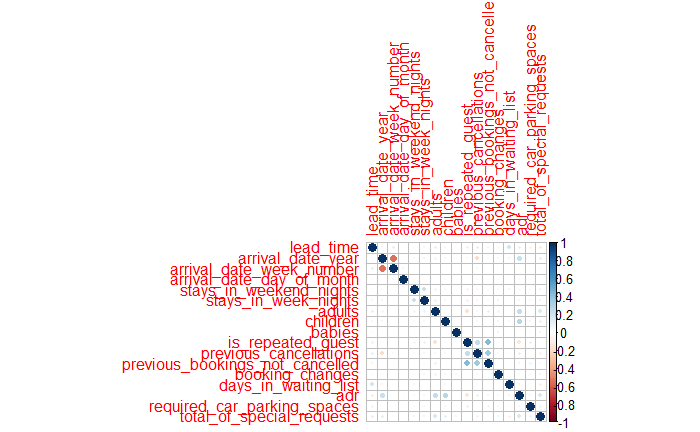

According to the plot, there are no noteworthy correlations between the numeric variables. However, is_repeated_guest and previous_bookings_not_cancelled provide the same information in essence. Therefore, we remove is_repeated, and use previous_bookings_not_cancelled which is more informative.

```r
bookings_train <- bookings_train %>%
  select(-is_repeated_guest)
```

## Time Variables

We create a date variable so that we can remove the separate variables for week, month, day, year

```r
bookings_train <- bookings_train %>%
  mutate(month = case_when(arrival_date_month == "January" ~ 1,
                                      arrival_date_month == "February" ~ 2,
                           arrival_date_month == "March" ~ 3,
                           arrival_date_month == "April" ~ 4,
                           arrival_date_month == "May" ~ 5,
                           arrival_date_month == "June" ~ 6,
                           arrival_date_month == "July" ~ 7,
                           arrival_date_month == "August" ~ 8,
                           arrival_date_month == "September" ~ 9,
                           arrival_date_month == "October" ~ 10,
                           arrival_date_month == "November" ~ 11,
                           arrival_date_month == "December" ~ 12))
bookings_train$date <-as.Date(with(bookings_train,paste(0, month,arrival_date_day_of_month,sep="-")),"%Y-%m-%d")
```

## New Variable: other_room_given

We believe that it is important if the guest was assigned the room type that s/he reserved. The variable gets the value “1” if the assigned room type doesn’t match the reserved.

```r
bookings_train <- bookings_train %>%
  mutate(other_room_given = case_when(reserved_room_type == assigned_room_type ~ 0,
                                      reserved_room_type != assigned_room_type ~ 1))
bookings_train$other_room_given <- as.factor(bookings_train$other_room_given)
```

## Relations with the target variable

We explore the relation between each numeric feature and the target variable.

```r
bookings_train %>% group_by(is_cancelled) %>%
  skim() %>%
  yank("numeric") %>% knit_print()
```

**Variable type: numeric**

| skim_variable | is_cancelled | n_missing | complete_rate | mean | sd | p0 | p25 | p50 | p75 | p100 | hist |
| --- | --- | --- | --- | --- | --- | --- | --- | --- | --- | --- | --- |
| lead_time | no | 0 | 1 | 81.21 | 89.92 | 0 | 12.0 | 51.00 | 121 | 518 | ▇▂▁▁▁ |
| lead_time | yes | 0 | 1 | 150.89 | 125.53 | 0 | 50.0 | 115.00 | 229 | 629 | ▇▃▂▁▁ |
| arrival_date_year | no | 0 | 1 | 2016.17 | 0.69 | 2015 | 2016.0 | 2016.00 | 2017 | 2017 | ▃▁▇▁▆ |
| arrival_date_year | yes | 0 | 1 | 2016.17 | 0.71 | 2015 | 2016.0 | 2016.00 | 2017 | 2017 | ▃▁▇▁▆ |
| arrival_date_week_number | no | 0 | 1 | 27.24 | 13.51 | 1 | 16.0 | 28.00 | 38 | 53 | ▅▇▇▇▅ |
| arrival_date_week_number | yes | 0 | 1 | 27.12 | 13.12 | 1 | 17.0 | 27.00 | 38 | 53 | ▅▇▇▇▅ |
| arrival_date_day_of_month | no | 0 | 1 | 15.81 | 8.73 | 1 | 8.0 | 16.00 | 23 | 31 | ▇▇▇▇▆ |
| arrival_date_day_of_month | yes | 0 | 1 | 15.78 | 8.72 | 1 | 8.0 | 16.00 | 23 | 31 | ▇▇▇▇▆ |
| stays_in_weekend_nights | no | 0 | 1 | 0.80 | 0.86 | 0 | 0.0 | 1.00 | 2 | 14 | ▇▁▁▁▁ |
| stays_in_weekend_nights | yes | 0 | 1 | 0.79 | 0.93 | 0 | 0.0 | 1.00 | 2 | 9 | ▇▂▁▁▁ |
| stays_in_week_nights | no | 0 | 1 | 2.13 | 1.38 | 0 | 1.0 | 2.00 | 3 | 34 | ▇▁▁▁▁ |
| stays_in_week_nights | yes | 0 | 1 | 2.27 | 1.57 | 0 | 1.0 | 2.00 | 3 | 24 | ▇▁▁▁▁ |
| adults | no | 0 | 1 | 1.83 | 0.53 | 0 | 2.0 | 2.00 | 2 | 4 | ▁▂▇▁▁ |
| adults | yes | 0 | 1 | 1.88 | 0.47 | 0 | 2.0 | 2.00 | 2 | 4 | ▁▂▇▁▁ |
| children | no | 0 | 1 | 0.10 | 0.38 | 0 | 0.0 | 0.00 | 0 | 3 | ▇▁▁▁▁ |
| children | yes | 0 | 1 | 0.08 | 0.35 | 0 | 0.0 | 0.00 | 0 | 3 | ▇▁▁▁▁ |
| babies | no | 0 | 1 | 0.01 | 0.12 | 0 | 0.0 | 0.00 | 0 | 10 | ▇▁▁▁▁ |
| babies | yes | 0 | 1 | 0.00 | 0.04 | 0 | 0.0 | 0.00 | 0 | 1 | ▇▁▁▁▁ |
| previous_cancellations | no | 0 | 1 | 0.02 | 0.31 | 0 | 0.0 | 0.00 | 0 | 13 | ▇▁▁▁▁ |
| previous_cancellations | yes | 0 | 1 | 0.17 | 0.53 | 0 | 0.0 | 0.00 | 0 | 21 | ▇▁▁▁▁ |
| previous_bookings_not_cancelled | no | 0 | 1 | 0.18 | 1.93 | 0 | 0.0 | 0.00 | 0 | 72 | ▇▁▁▁▁ |
| previous_bookings_not_cancelled | yes | 0 | 1 | 0.03 | 0.85 | 0 | 0.0 | 0.00 | 0 | 58 | ▇▁▁▁▁ |
| booking_changes | no | 0 | 1 | 0.26 | 0.68 | 0 | 0.0 | 0.00 | 0 | 18 | ▇▁▁▁▁ |
| booking_changes | yes | 0 | 1 | 0.08 | 0.42 | 0 | 0.0 | 0.00 | 0 | 9 | ▇▁▁▁▁ |
| days_in_waiting_list | no | 0 | 1 | 2.20 | 18.16 | 0 | 0.0 | 0.00 | 0 | 379 | ▇▁▁▁▁ |
| days_in_waiting_list | yes | 0 | 1 | 5.03 | 26.22 | 0 | 0.0 | 0.00 | 0 | 391 | ▇▁▁▁▁ |
| adr | no | 0 | 1 | 105.54 | 40.46 | 0 | 80.0 | 99.90 | 126 | 510 | ▇▇▁▁▁ |
| adr | yes | 0 | 1 | 105.10 | 55.81 | 0 | 76.5 | 99.68 | 126 | 5400 | ▇▁▁▁▁ |
| required_car_parking_spaces | no | 0 | 1 | 0.04 | 0.20 | 0 | 0.0 | 0.00 | 0 | 3 | ▇▁▁▁▁ |
| required_car_parking_spaces | yes | 0 | 1 | 0.00 | 0.00 | 0 | 0.0 | 0.00 | 0 | 0 | ▁▁▇▁▁ |
| total_of_special_requests | no | 0 | 1 | 0.74 | 0.83 | 0 | 0.0 | 1.00 | 1 | 5 | ▇▂▁▁▁ |
| total_of_special_requests | yes | 0 | 1 | 0.28 | 0.61 | 0 | 0.0 | 0.00 | 0 | 4 | ▇▂▁▁▁ |
| month | no | 0 | 1 | 6.57 | 3.06 | 1 | 4.0 | 7.00 | 9 | 12 | ▇▇▇▇▇ |
| month | yes | 0 | 1 | 6.55 | 2.99 | 1 | 4.0 | 7.00 | 9 | 12 | ▆▇▇▇▇ |

We create exploratory plots showing the relationships of individual features with the `is_cancelled` variable.

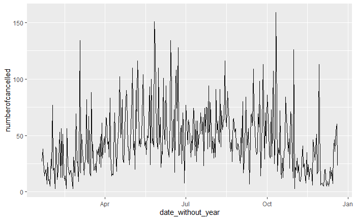

```r
bookings_train <- bookings_train %>% mutate(cancel_num= case_when(is_cancelled == "yes" ~ 1,
                                                is_cancelled == "no" ~ 0))

datedf <- bookings_train %>% select(cancel_num, date_without_year) %>% group_by(date_without_year)

datedf <- datedf %>% mutate(numberofcancelled=sum(cancel_num))
datedf %>%  ggplot(aes(x=date_without_year, y=numberofcancelled))+ geom_line() + scale_x_continuous(
                     labels = c("Jan", "Apr", "Jul", "Oct", "Jan"))
```

## Metrics of Interest

- The owner of the hotel is interested in accuracy and expecting the model to achieve 85% accuracy.
- Additionally, since the end-goal is to improve planning so that staffing, inventory and last-minute marketing activities can be optimized, predictions should be accurate for both classes in this binary problem. Therefore, we are interested in sensitivity and specificity. We can use balanced accuracy which gives an average of sensitivity and specificity.
- However, if the model causes the hotel to plan too little staff that is a bigger problem with more damage than if the hotel plans in too many people. Therefore,TNR/Specificity requires more attention.
- We will try to achieve 85% accuracy, 80% balanced accuracy and 90% specificity

## Splitting the data

We obtain a train and a test set by randomly dividing 80% of the rows of `bookings_train` for the training set and 20% for the test set:

```r
set.seed(238495)
p <- 0.8
ind_train <- createDataPartition(y= bookings_train$is_cancelled, p=p)
bookings_trn <- bookings_train %>% dplyr::slice(ind_train$Resample1)
bookings_tst <- bookings_train %>% dplyr::slice(-ind_train$Resample1)
c(train=nrow(bookings_trn), test =nrow(bookings_tst))
```

```
train  test
31732  7931
```

# Developing Models

## KNN

Country variable is eliminated for practical purposes.

```r
set.seed(238495)
ctrl <- trainControl(method = "cv", number = 5, selectionFunction = "best")
tune_grid <- expand.grid(k = 2 * (4:11) - 1)
book_train_cv <- train(is_cancelled ~ lead_time + deposit_type + adr + customer_type + date + market_segment + stays_in_week_nights + previous_cancellations + total_of_special_requests + other_room_given + booking_changes,
                data = bookings_trn, method = "knn",
                preProcess = c("center", "scale"),
                trControl = ctrl, tuneGrid = tune_grid)
book_train_cv
```

```
k-Nearest Neighbors

31732 samples
   11 predictor
    2 classes: 'no', 'yes'

Pre-processing: centered (16), scaled (16)
Resampling: Cross-Validated (5 fold)
Summary of sample sizes: 25386, 25385, 25386, 25385, 25386
Resampling results across tuning parameters:

  k   Accuracy   Kappa
   7  0.8154228  0.6141441
   9  0.8167779  0.6164551
  11  0.8181015  0.6184049
  13  0.8187318  0.6195462
  15  0.8187633  0.6191508
  17  0.8181645  0.6178305
  19  0.8182905  0.6179709
  21  0.8183851  0.6181464

Accuracy was used to select the optimal model using the largest value.
The final value used for the model was k = 15.
```

k=15 was chosen according to 5 fold CV results.

## Logistic Regression

```r
reformulate(termlabels = names(bookings_trn), response = "is_cancelled")
lm1 <- is_cancelled ~ lead_time +
    stays_in_weekend_nights + stays_in_week_nights + adults +
    children + babies + meal + market_segment +
    previous_cancellations + previous_bookings_not_cancelled +
    reserved_room_type + assigned_room_type + booking_changes +
    deposit_type + days_in_waiting_list + customer_type + adr +
    required_car_parking_spaces + total_of_special_requests +
    + date_without_year + other_room_given
```

Regularization: Lasso Logistic Regression

```r
ctrl <- trainControl(method = "cv", number = 5, selectionFunction = "best")
tuneGrid <-
  expand.grid(alpha = 1, lambda = 10^(seq(from = -4, to = -2, length.out = 20)))
set.seed(238495)
booking_glm_lasso <- train(lm1, data = bookings_trn, method = "glmnet",
                           family = "binomial",
                           trControl = ctrl, tuneGrid = tuneGrid)
booking_glm_lasso
```

```
glmnet

31732 samples
   21 predictor
    2 classes: 'no', 'yes'

No pre-processing
Resampling: Cross-Validated (5 fold)
Summary of sample sizes: 25386, 25385, 25386, 25385, 25386
Resampling results across tuning parameters:

  lambda        Accuracy   Kappa
  0.0001000000  0.8114520  0.5990107
  0.0001274275  0.8114835  0.5990734
  0.0001623777  0.8114520  0.5990110
  0.0002069138  0.8112944  0.5986635
  0.0002636651  0.8113890  0.5988608
  0.0003359818  0.8113259  0.5987008
  0.0004281332  0.8111684  0.5983081
  0.0005455595  0.8112629  0.5984689
  0.0006951928  0.8109478  0.5977361
  0.0008858668  0.8110738  0.5978971
  0.0011288379  0.8110423  0.5977080
  0.0014384499  0.8113259  0.5981469
  0.0018329807  0.8113889  0.5980682
  0.0023357215  0.8114519  0.5978976
  0.0029763514  0.8116410  0.5978861
  0.0037926902  0.8109792  0.5960094
  0.0048329302  0.8090884  0.5911785
  0.0061584821  0.8074812  0.5868570
  0.0078475997  0.8045188  0.5792443
  0.0100000000  0.8002960  0.5685173

Tuning parameter 'alpha' was held constant at a value of 1
Accuracy was used to select the optimal model using the largest value.
The final values used for the model were alpha = 1 and lambda = 0.002976351.
```

lambda = 0.002976351 was chosen according to 5 fold CV results.

## Decision Tree-Random Forest

We tried out different mtry values and chose mtry=6 based on OOB error estimates.

```r
booking_rf <- randomForest(rf_mod4_int, data = bookings_trn, mtry = 6, ntree = 300,
                         importance = TRUE, nPerm = 50)
booking_rf
```

```
Call:
 randomForest(formula = rf_mod4_int, data = bookings_trn, mtry = 6,      ntree = 300, importance = TRUE, nPerm = 50)
               Type of random forest: classification
                     Number of trees: 300
No. of variables tried at each split: 6

        OOB estimate of  error rate: 14.13%
Confusion matrix:
       no   yes class.error
no  16931  1561  0.08441488
yes  2922 10318  0.22069486
```

# Model Selection: Predicting for the Test Set

## KNN

```r
pred_test_knn <- predict(book_train_cv, newdata = bookings_tst, type = "prob")

con_kkn <- confusionMatrix(data = cut(pred_test_knn$yes, breaks = c(-Inf, 0.5, Inf),
                                       labels = c("no", "yes")),
                            reference = bookings_tst$is_cancelled,
                            positive = "yes", mode = "everything")
con_kkn
```

```
Confusion Matrix and Statistics

          Reference
Prediction   no  yes
       no  4194  982
       yes  428 2327

               Accuracy : 0.8222
                 95% CI : (0.8136, 0.8306)
    No Information Rate : 0.5828
    P-Value [Acc > NIR] : < 2.2e-16

                  Kappa : 0.6255

 Mcnemar's Test P-Value : < 2.2e-16

            Sensitivity : 0.7032
            Specificity : 0.9074
         Pos Pred Value : 0.8446
         Neg Pred Value : 0.8103
              Precision : 0.8446
                 Recall : 0.7032
                     F1 : 0.7675
             Prevalence : 0.4172
         Detection Rate : 0.2934
   Detection Prevalence : 0.3474
      Balanced Accuracy : 0.8053

       'Positive' Class : yes
```

## Logistic Regression

Model: is_cancelled ~ lead_time + stays_in_weekend_nights + stays_in_week_nights + adults + children + babies + meal + market_segment + previous_cancellations + previous_bookings_not_cancelled + reserved_room_type + assigned_room_type + booking_changes + deposit_type + days_in_waiting_list + customer_type + adr + required_car_parking_spaces + total_of_special_requests + date_without_year + other_room_given Lasso lambda= 0.002976351

```r
pred_test_log <- predict(booking_glm_lasso,
                        newdata = bookings_tst,
                        type = "prob")

conf_lr <- confusionMatrix(data = cut(pred_test_log$yes, breaks = c(-Inf, 0.5, Inf),
                                       labels = c("no", "yes")),
                            reference = bookings_tst$is_cancelled,
                            positive = "yes", mode = "everything")
conf_lr
```

```
Confusion Matrix and Statistics

          Reference
Prediction   no  yes
       no  4313 1208
       yes  309 2101

               Accuracy : 0.8087
                 95% CI : (0.7999, 0.8173)
    No Information Rate : 0.5828
    P-Value [Acc > NIR] : < 2.2e-16

                  Kappa : 0.5909

 Mcnemar's Test P-Value : < 2.2e-16

            Sensitivity : 0.6349
            Specificity : 0.9331
         Pos Pred Value : 0.8718
         Neg Pred Value : 0.7812
              Precision : 0.8718
                 Recall : 0.6349
                     F1 : 0.7347
             Prevalence : 0.4172
         Detection Rate : 0.2649
   Detection Prevalence : 0.3039
      Balanced Accuracy : 0.7840

       'Positive' Class : yes
```

## Random Forest

Model: is_cancelled ~ lead_time + stays_in_weekend_nights + stays_in_week_nights + adults + children + meal + market_segment + previous_cancellations + previous_bookings_not_cancelled + reserved_room_type + assigned_room_type + booking_changes + deposit_type + days_in_waiting_list + customer_type + adr + required_car_parking_spaces + total_of_special_requests * other_room_given + date mtry= 6 ntree= 300

```r
rf_test_pred <- predict(booking_rf,
                        newdata = bookings_tst,type = "prob")

rfpred_tibble <- rf_test_pred %>% as_tibble()

conf_rf <- confusionMatrix(data = cut(rfpred_tibble$yes, breaks = c(-Inf, 0.5, Inf),
                                       labels = c("no", "yes")),
                            reference = bookings_tst$is_cancelled,
                            positive = "yes", mode = "everything")
conf_rf
```

```
Confusion Matrix and Statistics

          Reference
Prediction   no  yes
       no  4255  757
       yes  367 2552

               Accuracy : 0.8583
                 95% CI : (0.8504, 0.8659)
    No Information Rate : 0.5828
    P-Value [Acc > NIR] : < 2.2e-16

                  Kappa : 0.7036

 Mcnemar's Test P-Value : < 2.2e-16

            Sensitivity : 0.7712
            Specificity : 0.9206
         Pos Pred Value : 0.8743
         Neg Pred Value : 0.8490
              Precision : 0.8743
                 Recall : 0.7712
                     F1 : 0.8195
             Prevalence : 0.4172
         Detection Rate : 0.3218
   Detection Prevalence : 0.3680
      Balanced Accuracy : 0.8459

       'Positive' Class : yes
```

## Model Comparison

```r
#Recode yes and no to 1 and 0
bookings_tst_vis <- bookings_tst %>%
  mutate(is_cancelled = case_when(is_cancelled == "yes" ~ 1,
                                                is_cancelled == "no" ~ 0))

# Put the data in matrices
pred_test_knn_mat <- as.matrix(pred_test_knn)
pred_test_log_mat <- as.matrix(pred_test_log)
pred_test_rf_mat <- as.matrix(rfpred_tibble)

# Select only the yes probabilities
pred_test_knn_mat = pred_test_knn_mat[,2]
pred_test_log_mat = pred_test_log_mat[,2]
pred_test_rf_mat = pred_test_rf_mat[,2]

# Load formula
source("calc_confusion.R")
conf_df <- calc_confusion(actual = bookings_tst_vis$is_cancelled,
                          positive = "1",
                          Model1 = pred_test_knn_mat, Model2 = pred_test_log_mat, Model3 = pred_test_rf_mat)
conf_df %>% head()
```

| Model | Probability | Actual_Positive | Actual_Negative | TN | FN | TP | FP |
| --- | --- | --- | --- | --- | --- | --- | --- |
| Model1 | -Inf | 0 | 0 | 0 | 0 | 3309 | 4622 |
| Model1 | 0.00000000 | 49 | 1025 | 1025 | 49 | 3260 | 3597 |
| Model1 | 0.02941176 | 0 | 3 | 1028 | 49 | 3260 | 3594 |
| Model1 | 0.03125000 | 0 | 1 | 1029 | 49 | 3260 | 3593 |
| Model1 | 0.03225806 | 0 | 1 | 1030 | 49 | 3260 | 3592 |
| Model1 | 0.03333333 | 0 | 2 | 1032 | 49 | 3260 | 3590 |

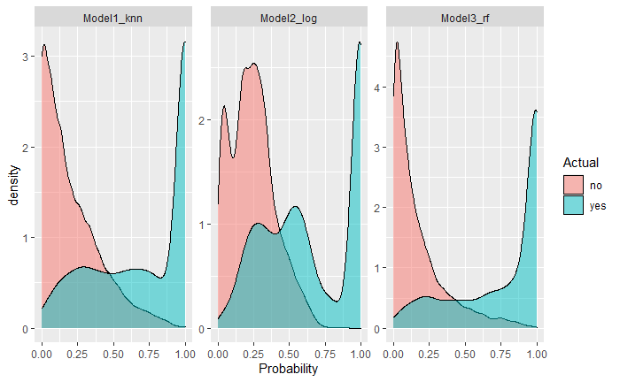

```r
preds <- tibble(Actual = bookings_tst$is_cancelled,
                Model1_knn = pred_test_knn_mat,
                Model2_log = pred_test_log_mat,
                Model3_rf = pred_test_rf_mat)
preds_long <- preds %>%
  pivot_longer(cols = -Actual, names_to = "Model", values_to = "Probability") %>%
  arrange(Model)

preds_long %>%
  ggplot(aes(x = Probability, fill = Actual)) +
  geom_density(alpha = 0.5) +
  facet_wrap(~ Model, scales = "free_y")
```

Obviously, Model 3 (randomforest) does a better job at separating the two classes.

## Removing and adding variables for the new data

We chose the random forest model based on the balanced accuracy and specificity values. Now we will predict for the test data.

```r
load("bookings_test_solutions.Rdata")
bookings_test_solutions <- bookings_test_solutions %>%
  mutate(month = case_when(arrival_date_month == "January" ~ 1,
                                      arrival_date_month == "February" ~ 2,
                           arrival_date_month == "March" ~ 3,
                           arrival_date_month == "April" ~ 4,
                           arrival_date_month == "May" ~ 5,
                           arrival_date_month == "June" ~ 6,
                           arrival_date_month == "July" ~ 7,
                           arrival_date_month == "August" ~ 8,
                           arrival_date_month == "September" ~ 9,
                           arrival_date_month == "October" ~ 10,
                           arrival_date_month == "November" ~ 11,
                           arrival_date_month == "December" ~ 12))
bookings_test_solutions$date <-as.Date(with(bookings_test_solutions,paste(arrival_date_year, month,arrival_date_day_of_month,sep="-")),"%Y-%m-%d")
bookings_test_solutions <- bookings_test_solutions %>%
  mutate(other_room_given = case_when(reserved_room_type == assigned_room_type ~ 0,
                                      reserved_room_type != assigned_room_type ~ 1))
bookings_test_solutions$other_room_given <- as.factor(bookings_test_solutions$other_room_given)
```

```r
final_test_pred <- predict(booking_rf,
                        newdata = bookings_test_solutions,type = "prob")

finalpred_tibble <- final_test_pred %>% as_tibble()

conf_final <- confusionMatrix(data = cut(finalpred_tibble$yes, breaks = c(-Inf, 0.5, Inf),
                                       labels = c("no", "yes")),
                            reference = bookings_test_solutions$is_cancelled,
                            positive = "yes", mode = "everything")
conf_final
```

```
Confusion Matrix and Statistics

          Reference
Prediction    no   yes
       no  21283  3652
       yes  1831 12897

               Accuracy : 0.8618
                 95% CI : (0.8583, 0.8651)
    No Information Rate : 0.5828
    P-Value [Acc > NIR] : < 2.2e-16

                  Kappa : 0.7112

 Mcnemar's Test P-Value : < 2.2e-16

            Sensitivity : 0.7793
            Specificity : 0.9208
         Pos Pred Value : 0.8757
         Neg Pred Value : 0.8535
              Precision : 0.8757
                 Recall : 0.7793
                     F1 : 0.8247
             Prevalence : 0.4172
         Detection Rate : 0.3252
   Detection Prevalence : 0.3713
      Balanced Accuracy : 0.8501

       'Positive' Class : yes
```